# Homework #4

Blake Inderski, btski

3/6/2019

```r
library("ggplot2")
library("dplyr")
library("datasets")
```

## Chick weights

The `ChickWeight` data set is part of the base package `datasets`. See `?ChickWeight` for details on the data. For all of the questions use `dplyr` functions with the pipe `%>%` whenever possible.

**Submission instructions**: Create a folder named `ds202_hw4`, and name the RMarkDown file including your solutions `hw4.Rmd` under this folder. For the submission, create a GitHub repository named `ds202_hw4` under your GitHub account, and push both `hw4.Rmd` and the knitted `hw4.html` before the deadline. I will assume you use the same GitHub username as for your HW3 submission. The latest version of your homework appearing on GitHub before the deadline is graded. *It is crucial to follow the exact folder structure and file names*, so that your homework can be reproduced and graded by an automated script. This homework is **due on March 7** before class.

1. Get a frequency breakdown of the number of chicks, their average weight and the standard deviation of the weights in each of the diets at the start of the study. Store the resulting data frame in a variable named `weight0` and print.

```r
data1 <- ChickWeight %>% filter(Time == 0)
weight0 <- group_by(data1, Diet) %>% summarise(n = n(), mean = mean(weight), stdv = sd(weight))
print(weight0)
```

```
## # A tibble: 4 x 4
##   Diet      n  mean  stdv
##   <fct> <int> <dbl> <dbl>
## 1 1        20  41.4 0.995
## 2 2        10  40.7 1.49
## 3 3        10  40.8 1.03
## 4 4        10  41   1.05
```

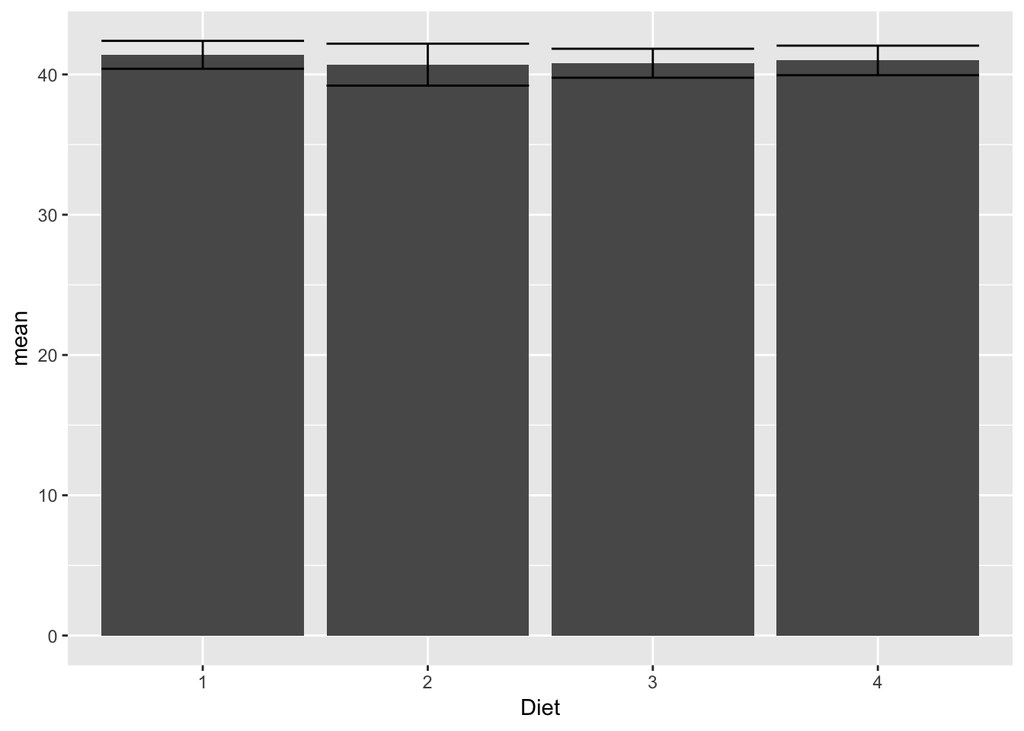

```r
plot1 <- ggplot(weight0, aes(x=Diet, y=mean)) + geom_bar(stat="identity") + geom_errorbar(aes(ymin=mean-stdv, ymax=mean+stdv))
plot1
```

2. Each chick should have twelve weight measurements. Use the dplyr package to identify how many measurements are there for each chick. Extract a subset of the data for all chicks with complete information, name the data set `complete`, and print the first 3 rows. (Hint: you might want to use mutate to introduce a helper variable consisting of the number of observations)

```r
check_complete <- group_by(ChickWeight, Chick) %>% summarise(n = n())
check_vector <- check_complete %>% filter(n == max(check_complete$n)) %>% pull(Chick)
complete <- ChickWeight %>% filter(Chick %in% check_vector)
print(complete[0:3, ])
```

```
##   weight Time Chick Diet
## 1     42    0     1    1
## 2     51    2     1    1
## 3     59    4     1    1
```

3. In the complete data set introduce a new variable that measures the current weight difference compared to day 0. Name this variable `weightgain` and print the first 3 rows of the new data frame.

```r
complete <- group_by(complete, Chick) %>% arrange(Chick, Time) %>% mutate(weightgain = weight - first(weight))
print(complete[0:3, ])
```

```
## # A tibble: 3 x 5
## # Groups:   Chick [1]
##   weight  Time Chick Diet  weightgain
##    <dbl> <dbl> <ord> <fct>      <dbl>
## 1     41     0 13    1              0
## 2     48     2 13    1              7
## 3     53     4 13    1             12
```

4. Use `{ggplot2}` to create side-by-side boxplots of `weightgain` by `Diet` for day 21. Describe the relationship in 2-3 sentences. Change the order of the categories in the Diet variable such that the boxplots are ordered by median `weightgain`, and the lower limit of the y axis should be 0.

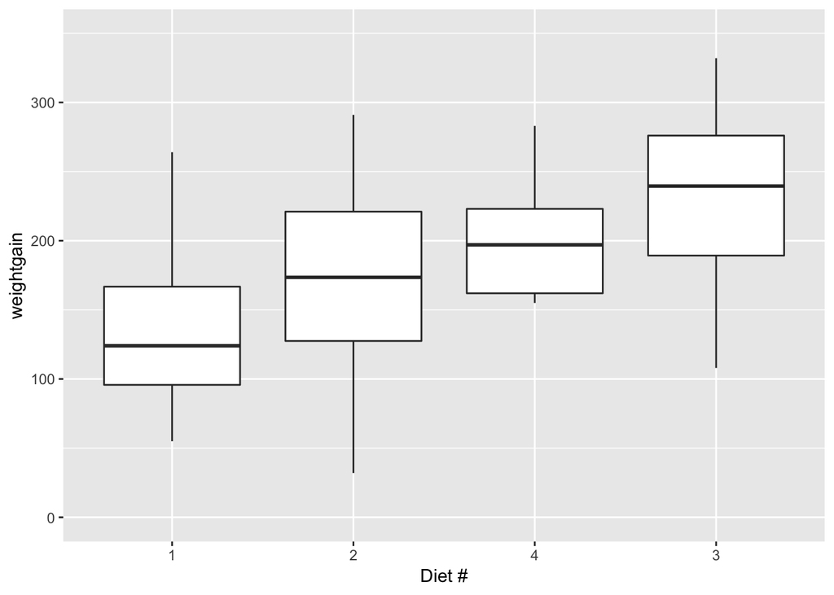

```r
data2 <- complete %>% filter(Time == 21)
plot2 <- ggplot(data2, aes(x=reorder(Diet, weightgain, FUN=median), y=weightgain)) + geom_boxplot() + ylim(0, 350) + xlab("Diet #")
plot2
```

5. Answer the following question using numerical and graphical summary: Which chick gained the most weight and which gained the least weight? What diets were they on?

```r
most_growth <- data2 %>% filter(weightgain == max(data2$weightgain))
least_growth <- data2 %>% filter(weightgain == min(data2$weightgain))
summary(most_growth)
```

```
##      weight         Time        Chick   Diet    weightgain
##  Min.   :373   Min.   :21   35     :1   1:0   Min.   :332
##  1st Qu.:373   1st Qu.:21   18     :0   2:0   1st Qu.:332
##  Median :373   Median :21   16     :0   3:1   Median :332
##  Mean   :373   Mean   :21   15     :0   4:0   Mean   :332
##  3rd Qu.:373   3rd Qu.:21   13     :0         3rd Qu.:332
##  Max.   :373   Max.   :21   9      :0         Max.   :332
##                             (Other):0
```

```r
summary(least_growth)
```

```
##      weight        Time        Chick   Diet    weightgain
##  Min.   :74   Min.   :21   24     :1   1:0   Min.   :32
##  1st Qu.:74   1st Qu.:21   18     :0   2:1   1st Qu.:32
##  Median :74   Median :21   16     :0   3:0   Median :32
##  Mean   :74   Mean   :21   15     :0   4:0   Mean   :32
##  3rd Qu.:74   3rd Qu.:21   13     :0         3rd Qu.:32
##  Max.   :74   Max.   :21   9      :0         Max.   :32
##                            (Other):0
```

```r
#https://stackoverflow.com/questions/14351608/color-one-point-and-add-an-annotation-in-ggplot2
data2$highlight <- ifelse(data2$weightgain == max(data2$weightgain), "max", "other")
data2$highlight[data2$weightgain == min(data2$weightgain)] <- 'min'
data2
```

```
## # A tibble: 45 x 6
## # Groups:   Chick [45]
##    weight  Time Chick Diet  weightgain highlight
##     <dbl> <dbl> <ord> <fct>      <dbl> <chr>
##  1     96    21 13    1             55 other
##  2     98    21 9     1             56 other
##  3    117    21 20    1             76 other
##  4    124    21 10    1             83 other
##  5    142    21 17    1            100 other
##  6    157    21 19    1            114 other
##  7    157    21 4     1            115 other
##  8    157    21 6     1            116 other
##  9    175    21 11    1            132 other
## 10    202    21 3     1            159 other
## # … with 35 more rows
```

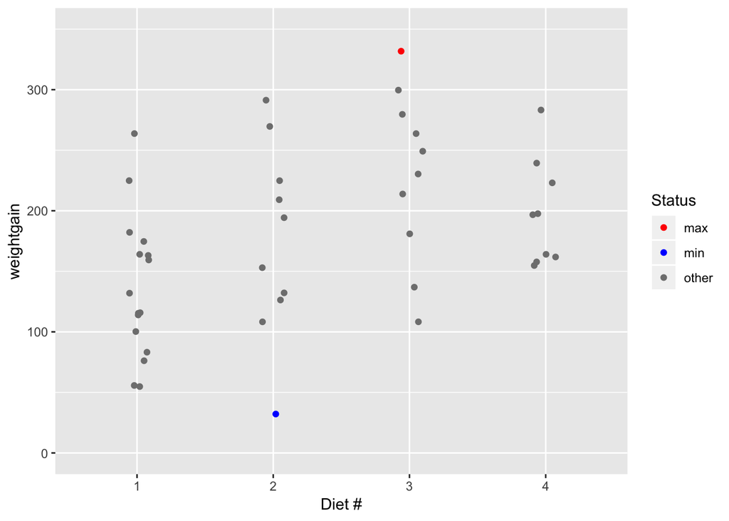

```r
mycolors <- c("max" = "red", "min" = "blue", "other" = "grey50")
ggplot(data2, aes(x=Diet, y=weightgain, color=highlight)) + scale_color_manual("Status", values = mycolors) + geom_jitter(width=0.1) + ylim(0, 350) + xlab("Diet #")
```

Chick 35 gained the most weight (332) on diet 3. Chick 24 gained the least weight (32) on diet 2.

6. For the chicks with the least and the most weight at time 0, plot their growth trajectories over time.

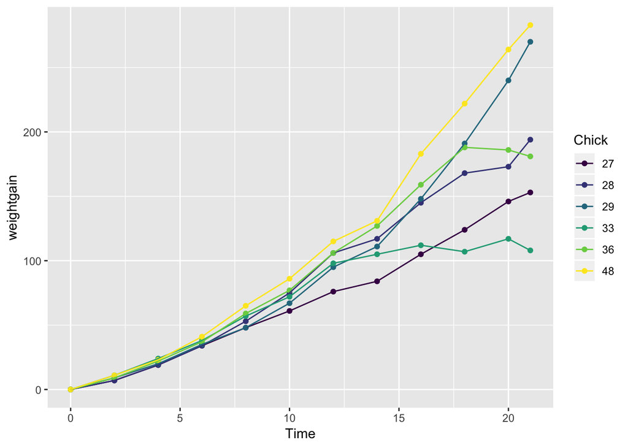

```r
small_chick_vector <- group_by(complete, Time) %>% filter(Time == 0) %>% mutate(min_weight = min(weight)) %>% filter(weight == min_weight) %>% pull(Chick)
big_chick_vector <- group_by(complete, Time) %>% filter(Time == 0) %>% mutate(max_weight = max(weight)) %>% filter(weight == max_weight) %>% pull(Chick)

data3 <- complete %>% filter(Chick %in% small_chick_vector)
data4 <- complete %>% filter(Chick %in% big_chick_vector)
plot3 <- ggplot(data3, aes(x=Time, y=weightgain)) + geom_point(aes(color=Chick)) + geom_line(aes(color=Chick))
plot4 <- ggplot(data4, aes(x=Time, y=weightgain)) + geom_point(aes(color=Chick)) + geom_line(aes(color=Chick))
plot3
```

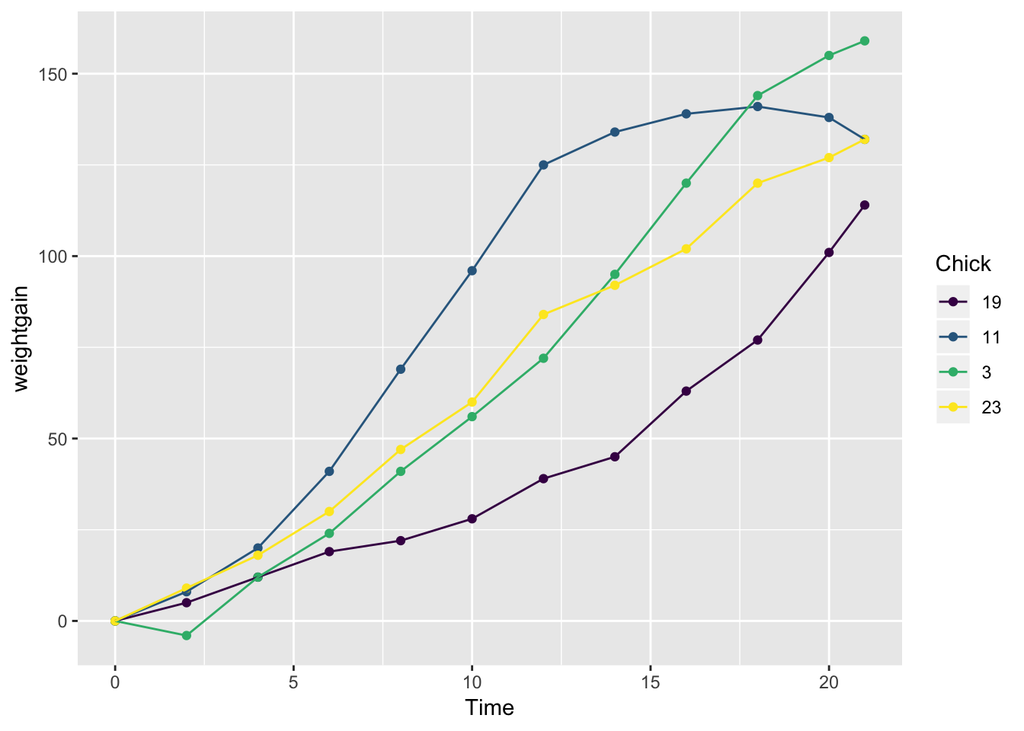

```r
plot4
```

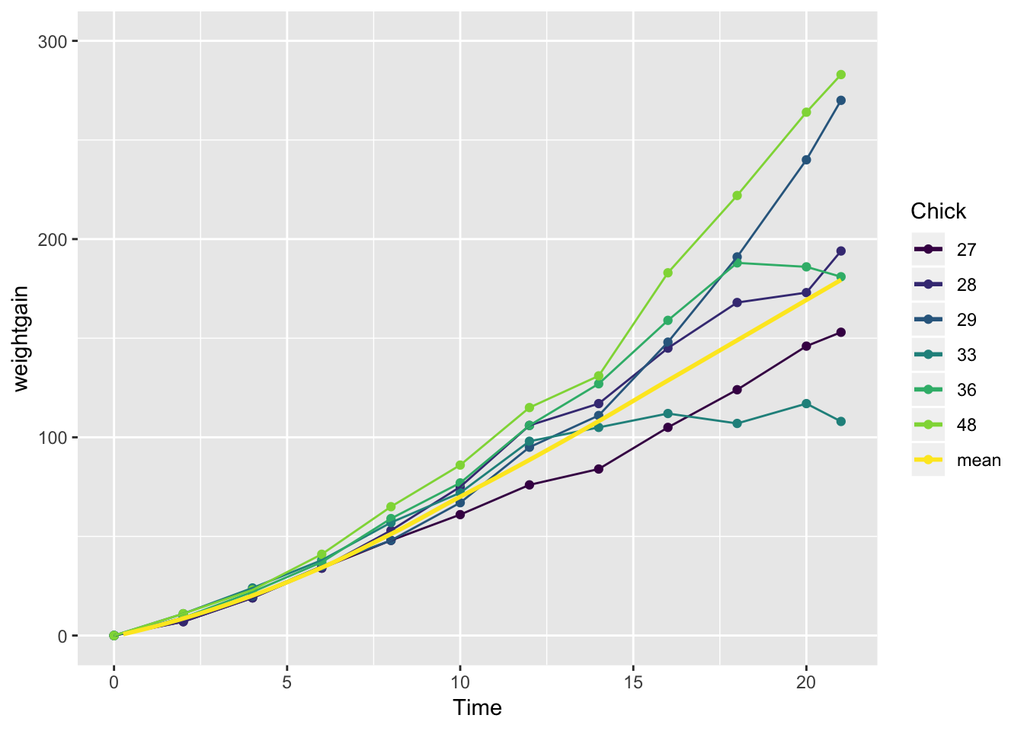

```r
data5 <- group_by(complete, Time) %>% summarise(mean = mean(weightgain))
plot3 + geom_smooth(data=data5, aes(x=Time, y=mean, color="mean"), se=F) + ylim(0, 300)
```

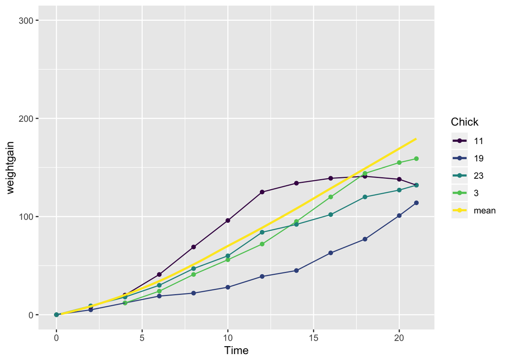

```r
plot4 + geom_smooth(data=data5, aes(x=Time, y=mean, color="mean"), se=F) + ylim(0, 300)
```

Chicks with minimum starting weight tend to exceed the mean growth rate. Chicks with maximum starting weight had a growth rate less than the mean.

7. What else do you find interesting in the dataset? Show your exploratory analysis.

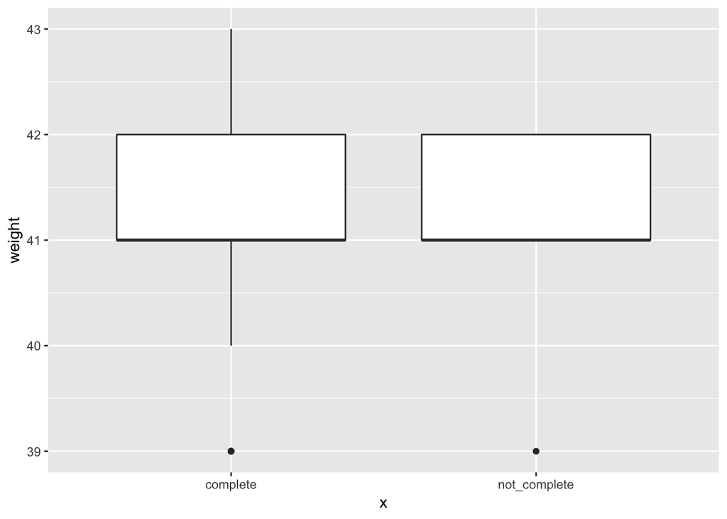

```r
#explore growth of pigs that do not have complete records.
check_complete <- group_by(ChickWeight, Chick) %>% summarise(n = n())
check_vector <- check_complete %>% filter(n == max(check_complete$n)) %>% pull(Chick)
not_complete <- group_by(ChickWeight, Chick) %>% filter(!(Chick %in% check_vector)) %>% arrange(Chick, Time) %>% mutate(weightgain = weight - first(weight))
#nrow(not_complete)
ggplot() + geom_boxplot(data=complete[complete$Time == 0, ], aes(x="complete", y=weight)) + geom_boxplot(data=not_complete[not_complete$Time == 0, ], aes(x="not_complete", y=weight))
```

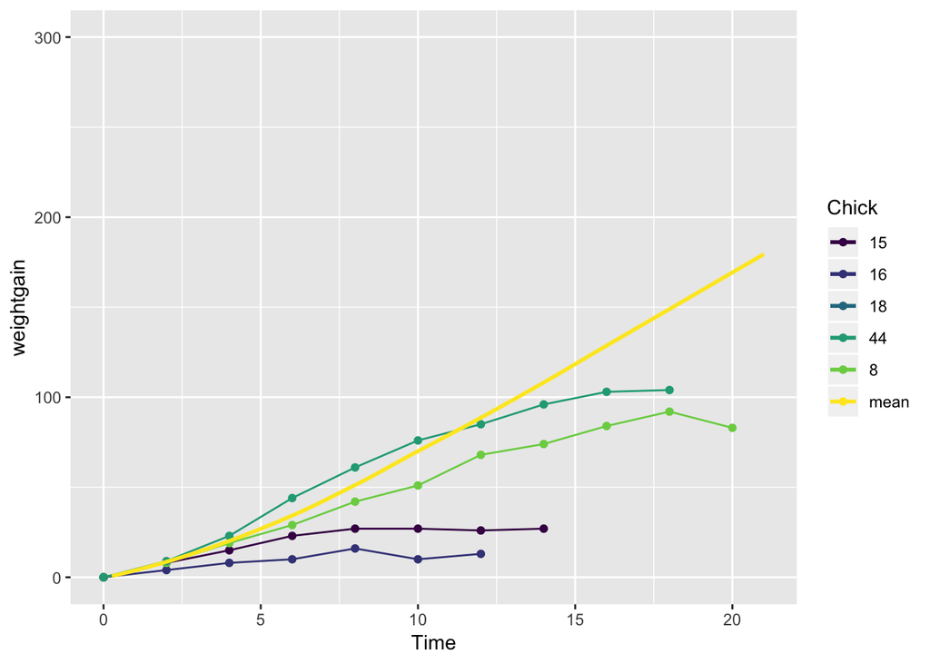

```r
ggplot(not_complete, aes(x=Time, y=weightgain)) + geom_point(aes(color=Chick)) + geom_line(aes(color=Chick)) + geom_smooth(data=data5, aes(x=Time, y=mean, color="mean"), se=F) + ylim(0, 300)
```

Chose to compare some aspects of the complete/incomplete data. Starting weight can influence growth rate; starting weight was largely similar between both sets. Growth rates were less than the average and platued prior to ending prematurely. This suggests that the animals contracted an illness and died prior to the completion of the study.

Note: your submission is supposed to be fully reproducible, i.e. the TA and I will ‘knit’ your submission in RStudio.